title: “COMPSCIX 415.2 Homework 3” author: “Ganesh Saravanan” date: “6/25/2018” output: pdf_document

My Github repository for my assignments can be found at this URL:https://github.com/gsaravanan1/rstudiodemo.git

```r
library(mdsr)
library(tidyverse)
library(ggplot2)
library(nycflights13)
```

3.8.1 Exercises 1. What is the problem with this plot? How could you improve it?

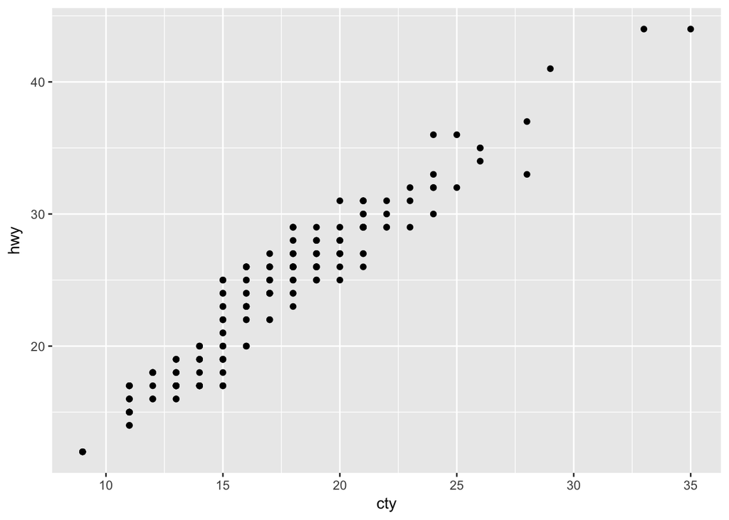

```r
ggplot(data = mpg, mapping = aes(x = cty, y = hwy)) +
  geom_point()
```

ANSWER: Add a small amount of random variation

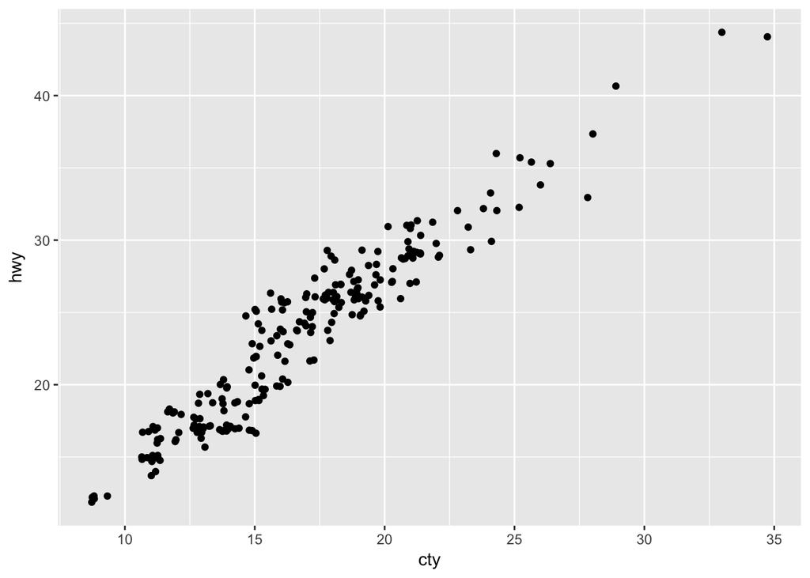

```r
ggplot(data = mpg, mapping = aes(x = cty, y = hwy)) +
  geom_jitter()
```

2. What parameters to geom_jitter() control the amount of jittering?

ANSWER: width and height.

3. Compare and contrast geom_jitter() with geom_count().

ANSWER: Jittering is adding a small amount of random noise to data. It is often used to spread out points that would otherwise be overplotted. It is only effective in the non-continuous data case where overplotted points typically are surrounded by whitespace - jittering the data into the whitespace allows the individual points to be seen. It effectively un-discretizes the discrete data.

4. What’s the default position adjustment for geom_boxplot()? Create a visualisation of the mpg dataset that demonstrates it.

ANSWER: The default position adjustment is position_dodge().

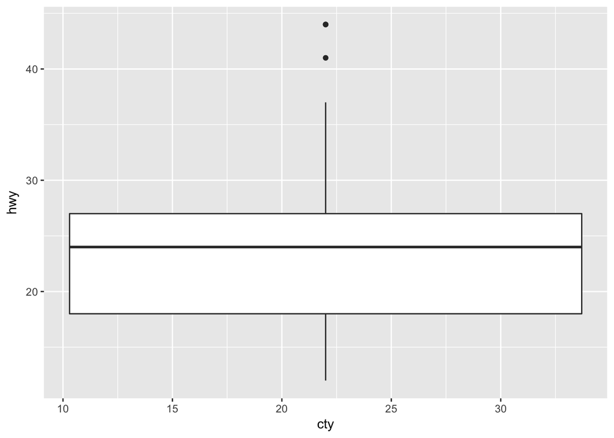

```r
ggplot(data = mpg, mapping = aes(x = cty, y = hwy)) +
  geom_boxplot(position = "dodge")
```